# Titanic_survival_analysis_report

YutongLIU

2016年12月19日

This is the first time I tried to do a data analysis practice by myself after data science course. Any comments and recommendation about this practice is welcome :)

Here is the agenda of this report

#### 1 Introduction

#### 2 Defining the Question

- 2.1 What is the outcome we want?
- 2.2 What data can we use to answer the question?

#### 3 Feature Engineering

- 3.1 Missing data imputation
- 3.2 Which varialbes may be relevant to the outcome?
  - 3.2.1 Higher Passenger class, more possible to survive?
  - 3.2.2 Children and women first?
  - 3.2.3 Families can help each other?
  - 3.2.4 Is cabin location relevant to the passenger survival?
  - 3.2.5 Is there any more information we can grab from passengers name?

#### 4 Prediction

#### 5 Conclusions

#### 1 Introduction

With this dataset, let’s find out if it’s possible to predict Titanic passengers’ survival based on their profile.

Firstly I downloaded the dataset here [kaggle](https://www.kaggle.com/c/titanic)

##### Set working directory

```r
# Set working directory
if(!dir.exists("D:/kaggle/kaggle_Titanic"))
        dir.create("D:/kaggle/kaggle_Titanic")
setwd("D:/kaggle/kaggle_Titanic")

# Load packages
library(dplyr)   # cleaning dataset
library(ggplot2) # drawing graphics for exploratory analysis
library(rpart)   # missing data imputation
library(caret)   # prediction
library(randomForest) #prediction
```

##### Loading training dataset

Here are the reasons why I save integer variables in different formats + **Survived**: I think it’s nomial variable, so I save it as factor. + **Pclass** : I think it’s ordinal variable, so I save it as integer. + **Sibsp** and **Parch**: maybe I will try to calculate some new variables, so keep them as integer.

```r
# Download and read dataset
colclass <- c("integer","factor","integer","character",
            "factor","numeric","integer","integer",
            "character","numeric","character","factor")
train_raw <- read.csv(file="./train.csv", header = TRUE,
                      colClasses = colclass,
                       na.strings = c("","NA"),stringsAsFactors = FALSE)

# Do the same process to the test set
# There is no "survived" variable, so change the column class
colclass_test<-c("integer","integer","character",
            "factor","numeric","integer","integer",
            "character","numeric","character","factor")
test_raw <- read.csv(file="./test.csv", header=TRUE,
                     colClasses=colclass_test,
                      na.strings = c("","NA"),stringsAsFactors = FALSE)
```

Now let’s have a glance at the dataset

```r
str(train_raw)
```

[output not shown]

There are 11 variables(**PassengerID** excluded), here is the definition of each variables.

| Variable | Description |
| --- | --- |
| survival | Survival(0 = No; 1 = Yes) |
| pclass | Passenger Class(1 = 1st; 2 = 2nd; 3 = 3rd) |
| name | Passenger name |
| sex | Sex |
| age | Age |
| sibsp | Number of siblings/spouses aboard |
| parch | Number of parents/children aboard |
| ticket | Ticket number |
| fare | Passenger fare |
| cabin | Cabin |
| embarked | Port of Embarkation(C = Cherbourg; Q = Queenstown; S = Southampton) |

#### 3 Feature Engineering

- 3.1 Dataset cleaning and Missing data imputation

### 3.1.1 Dataset cleaning

#### Combination

To ensure the preprocess is the same to train and also test set, now we combine them together.

```r
total_raw <- bind_rows(train_raw,test_raw)

# Save dataset in a new data frame
total_clean <- total_raw
```

#### Text Editing

Firstly, let’s check the variable names, are they easy to use? Fortunately there is no space among the variable names. Now I just standardize them in lower case.

```r
# Standardize all variable names in lower case and check
names(total_clean) <- tolower(names(total_raw))
colnames(total_clean)
```

### 3.1.2 Missing value inputation

#### a) Counting missing values in each variable

```r
na_count<-summary(apply(total_clean,2,is.na))
```

From the table below, we learned that there are NA values in several variables Because the dataset contains the test set, there should be missing values in **survived** so it won’t be shown in the table, and **passengerid** won’t be used as predictor, therefore it won’t be shown in the table neither.

| Variables | NA values # |
| --- | --- |
| pclass | Mode :logical , FALSE:1309 , NA’s :0 , NA |
| name | Mode :logical , FALSE:1309 , NA’s :0 , NA |
| sex | Mode :logical , FALSE:1309 , NA’s :0 , NA |
| age | Mode :logical , FALSE:1046 , TRUE :263 , NA’s :0 |
| sibsp | Mode :logical , FALSE:1309 , NA’s :0 , NA |
| parch | Mode :logical , FALSE:1309 , NA’s :0 , NA |
| ticket | Mode :logical , FALSE:1309 , NA’s :0 , NA |
| fare | Mode :logical , FALSE:1308 , TRUE :1 , NA’s :0 |
| cabin | Mode :logical , FALSE:295 , TRUE :1014 , NA’s :0 |
| embarked | Mode :logical , FALSE:1307 , TRUE :2 , NA’s :0 |

#### b) Finding observations that contain missing value and process

##### 1 Age

There are 263 NA values in variable **age**.

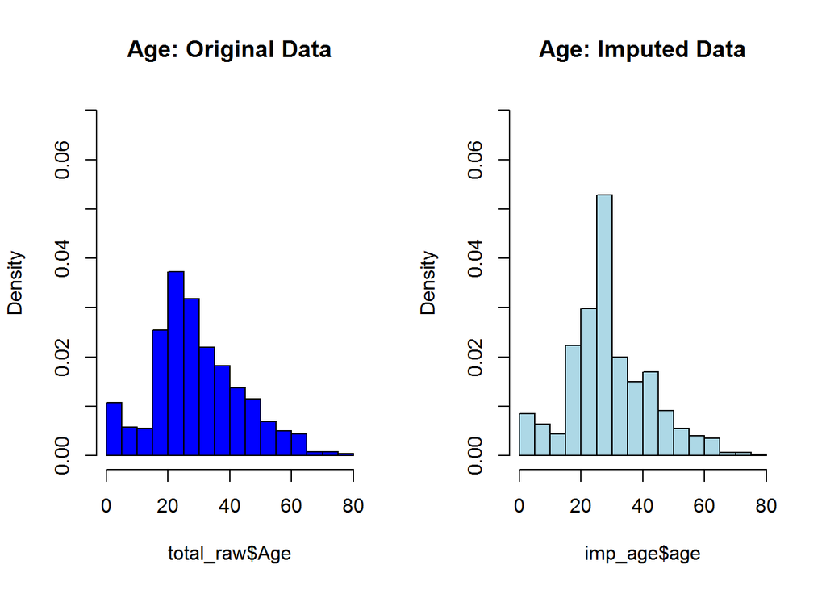

```r
set.seed(123)
factor_name<-c("survived","sex")
total_clean[factor_name]<-lapply(total_clean[factor_name], function(x) as.factor(x))
# Age missing value imputation with rpart
fit_age <- rpart(age ~ pclass+sex+sibsp+parch,
               data=total_clean[!is.na(total_clean$age),3:12],
               na.action=na.omit,method = "anova")
age_result <- predict(fit_age,total_clean[,3:12])
age_result <- round(age_result)
imp_age<-total_clean[,6]
imp_age[is.na(imp_age)]<-age_result[is.na(imp_age)]

# plot age distribution
par(mfrow=c(1,2))
hist(total_raw$Age, freq=F, main='Age: Original Data',col='blue',
     ylim=c(0,0.07))
hist(imp_age$age, freq=F,main='Age: Imputed Data',col='lightblue',
     ylim=c(0,0.07))
```

```r
#impute missing value in age
total_clean$age<-imp_age$age
sum(is.na(total_clean$age))
```

```
## [1] 0
```

##### 2 Fare

After checking the observation with NA in fare, we find that this passenger is third class and embarked from Southampton. Based on the distribution of third class ticket fare from Southampton, we use the median to impute the NA value.

```r
# Check the observation with NA in fare
total_clean[is.na(total_clean$fare),1:12]
```

```
## Source: local data frame [1 x 12]
##
##   passengerid survived pclass               name    sex   age sibsp parch
##         (int)   (fctr)  (int)              (chr) (fctr) (dbl) (int) (int)
## 1        1044       NA      3 Storey, Mr. Thomas   male  60.5     0     0
## Variables not shown: ticket (chr), fare (dbl), cabin (chr), embarked
##   (fctr)
```

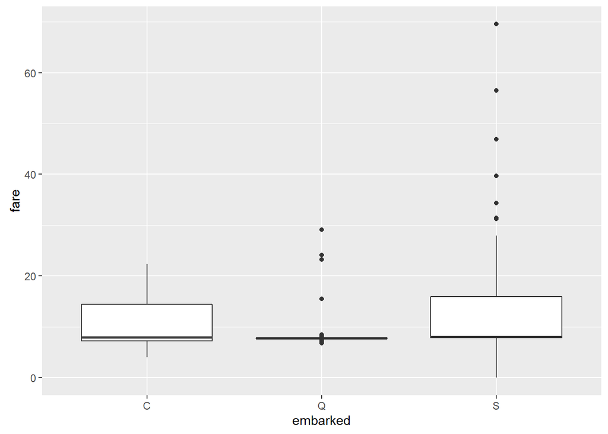

```r
# distribution of fare
g_fare<-ggplot(data =total_clean[which(total_clean$pclass==3),],
               aes(embarked,fare))
g_fare+geom_boxplot()
```

```r
total_clean[is.na(total_clean$fare),"fare"]<-
        median(total_clean[total_clean$pclass=="3"&total_clean$embarked =="S",]$fare,na.rm = TRUE)
```

##### 3 Embarked

Two observations with missing value in embarked have the same ticket fare: 80 From the plot, this fare appears more likely among passengers emarked from Cherbourg. So these two observations embarked missing value are assigned to ‘C’.

```r
# Find the missing value in which observation
total_clean[is.na(total_clean$embarked),]
```

```
## Source: local data frame [2 x 12]
##
##   passengerid survived pclass                                      name
##         (int)   (fctr)  (int)                                     (chr)
## 1          62        1      1                       Icard, Miss. Amelie
## 2         830        1      1 Stone, Mrs. George Nelson (Martha Evelyn)
## Variables not shown: sex (fctr), age (dbl), sibsp (int), parch (int),
##   ticket (chr), fare (dbl), cabin (chr), embarked (fctr)
```

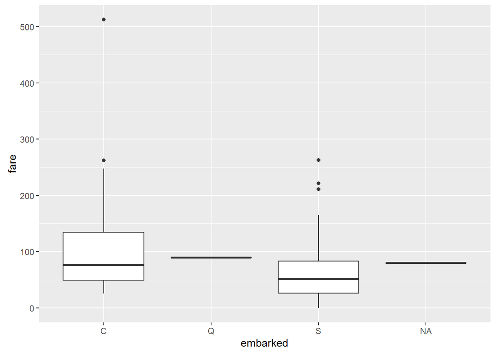

```r
# Fare vs Embarked
gfare <- ggplot(total_clean[total_clean$pclass==1,],aes(x=embarked,y=fare))
gfare+geom_boxplot()
```

```r
total_clean$embarked[c(62, 830)] <- 'C'
```

#### 3.2 Which varialbes may be relevant to the outcome?

##### 3.2.1 Higher Passenger class, more possible to survive?

From the barchart, it seems that higher passenger class is, more possible to survive.

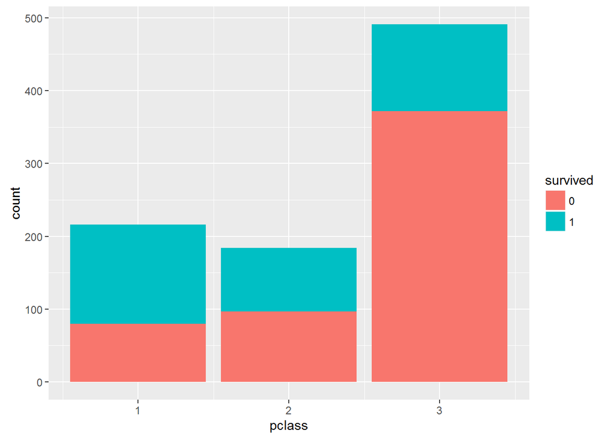

```r
gpclass<-ggplot(total_clean[1:891,],aes(pclass,fill = survived))
gpclass+geom_bar()
```

##### 3.2.2 Children and women first? Obviously female passengers are more likely to survive.

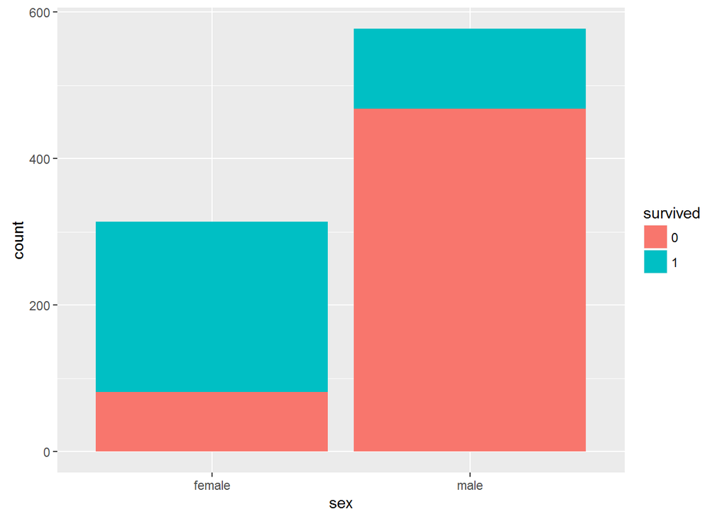

```r
ggender<-ggplot(total_clean[1:891,],aes(sex,fill = survived))
ggender+geom_bar()
```

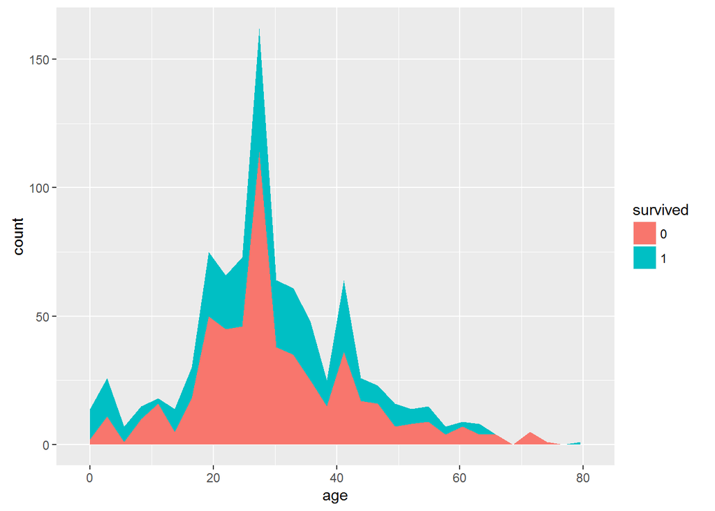

```r
gage <- ggplot(total_clean[1:891,],aes(age,,fill = survived))
gage+geom_area(stat = "bin")
```

##### 3.2.3 Families can help each other?

```r
family_size<-total_clean$sibsp+total_clean$parch+1
total_clean<-mutate(total_clean,familynumber=family_size)
#family_size[family_size > 4]<-"large"
#family_size[family_size > 1 & family_size < 5]<-"small"
#family_size[family_size == 1]<-"single"
#total_clean<-mutate(total_clean,familysize=as.factor(family_size))
```

##### 3.2.4 Is cabin location relevant to the passenger survival?

I found some information on the internet, it indicates that the initials in cabin number depends on cabin location, class and price. So I tried to grab the initials of cabin.

```r
cabin_survived <-  total_clean[1:891,c("survived","cabin")]

# Grab the beginning letter in cabin number
cabin_survived$cabin<-gsub("[0-9]","",cabin_survived$cabin)

# Coerce into a factor vector
unique(cabin_survived$cabin)
```

```
##  [1] NA        "C"       "E"       "G"       "D"       "A"       "C C C"
##  [8] "B"       "F"       "F G"     "D D"     "B B"     "F E"     "C C"
## [15] "B B B B" "T"       "B B B"
```

```r
cabin_survived$cabin<-as.factor(cabin_survived$cabin)

# Combine factor levels(there are some observation with multiple letter in cabin, like 'B20 B10 B3'
cabin_level<-c("C","E","G","D","A","C","B","F","F","D","B","E","C","B","T","B","E")
levels(cabin_survived$cabin)<-cabin_level
```

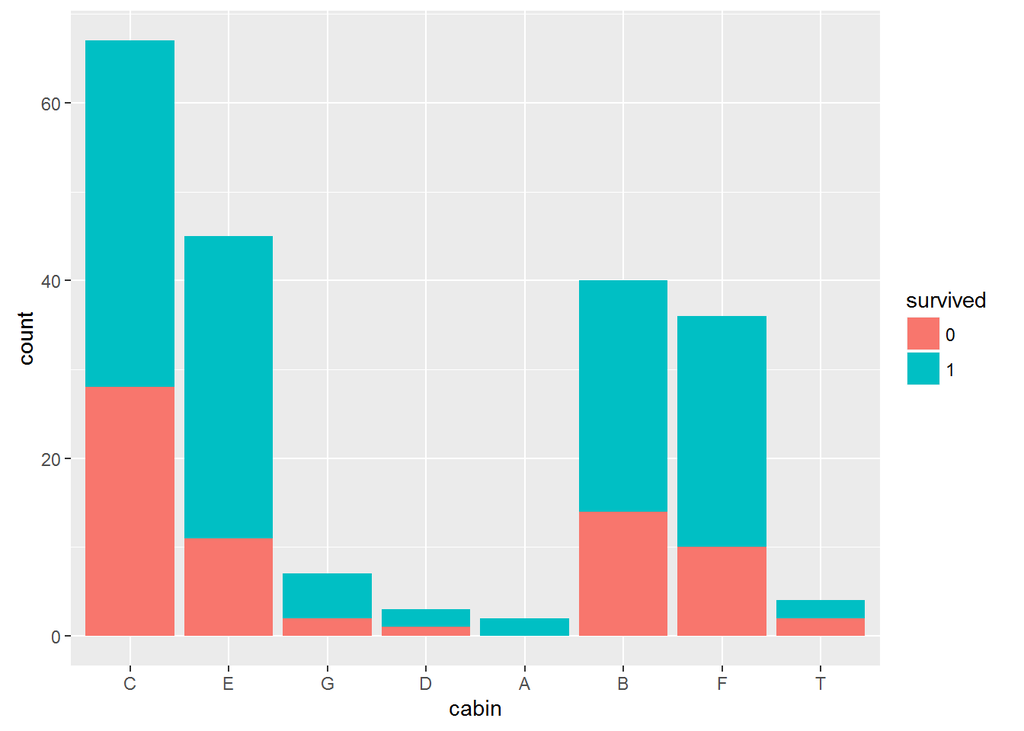

```r
# Cabin vs survival
g_cabin <- ggplot(data = cabin_survived[!is.na(cabin_survived$cabin),],
                aes(cabin,fill=survived))
g_cabin+geom_bar()
```

##### 3.2.5 Is there any more information we can grab from passengers name?

Address from passenger name

```r
# Variable "Name" contains two types of information:
# name and also sex&marital status
# Extract sexmarital status

nametitle<-gsub("(.*, )|(\\..*)","",x=total_clean$name)

#As the factor levels in the train dataset may be different from the test set
#So we don't coerse this variable into factor.

#there are some repeated title so we combined those titles.
special_male<-c("Capt","Col","Don","Dr","Jonkheer",
                "Major","Master","Rev","Sir","the Countess")
special_female<-c("Lady","Dona","Mlle","Mme","Ms")
nametitle[nametitle %in% special_male]<- "Special_male"
nametitle[nametitle %in% special_female]<- "Special_female"

total_clean<-mutate(total_clean,title=nametitle)
total_clean$title<-as.factor(total_clean$title)
```

### Feature & Model selection

Based on exploratory analysis, pclass, sex,age, fare, title and familysize are selected to train model.

```r
# Split back into train and test sets
trainset<-total_clean[1:891,]
testset<-total_clean[892:1309,]
```

```r
model_rf1<-randomForest(survived ~ pclass + sex + age + fare +
                          title + familynumber,
                  data = trainset)
```

### Prediction

```r
rf1_result<-predict(model_rf1,trainset)
confusionMatrix(trainset$survived,rf1_result)
```

```
## Confusion Matrix and Statistics
##
##           Reference
## Prediction   0   1
##          0 526  23
##          1  66 276
##
##                Accuracy : 0.9001
##                  95% CI : (0.8785, 0.919)
##     No Information Rate : 0.6644
##     P-Value [Acc > NIR] : < 2.2e-16
##
##                   Kappa : 0.7837
##  Mcnemar's Test P-Value : 8.508e-06
##
##             Sensitivity : 0.8885
##             Specificity : 0.9231
##          Pos Pred Value : 0.9581
##          Neg Pred Value : 0.8070
##              Prevalence : 0.6644
##          Detection Rate : 0.5903
##    Detection Prevalence : 0.6162
##       Balanced Accuracy : 0.9058
##
##        'Positive' Class : 0
##
```

```r
importance(model_rf1)
```

```
##              MeanDecreaseGini
## pclass               32.65541
## sex                  60.92703
## age                  48.25597
## fare                 59.68223
## title                68.38037
## familynumber         25.86545
```

### Predict with test data

```r
# pay attention to the type of every predictor!
testset<-total_clean[892:1309,]

test_result<-predict(model_rf1,testset)
titanic_rf_submission<-
        data.frame(Passengerid = testset$passengerid,
                   Survived = test_result)
write.csv(x = titanic_rf_submission,
          file = "./titanic_rf_submission7.csv",row.names = FALSE)
```